# MiniProject1_Stoneman

Hayley Stoneman

2/18/2021

```r
knitr::opts_chunk$set(echo = TRUE)
library(tidyverse)
library(magrittr)
library(bigrquery)
library(gridExtra)
library(lubridate)
#establish connection
con <- DBI::dbConnect(drv = bigquery(),
                      project = "learnclinicaldatascience")
```

## Data Type

**Data Type:** For this project the data type of interest is encounters.

Start by loading the MIMIC-III admissions table.

```r
admissions <- tbl(con, 'mimic3_demo.ADMISSIONS') %>%
  select(-ROW_ID)
```

[output not shown]

```
## The bigrquery package is using a cached token for hayley.idance@gmail.com.
```

```
## Auto-refreshing stale OAuth token.
```

Look at the first couple of rows of data and the included columns (column names).

```r
admissions_df <- as.data.frame(admissions)

admissions_df %>%
  DT::datatable(options = list(scrollX = T))
```

|  | SUBJECT_ID | HADM_ID | ADMITTIME | DISCHTIME | DEATHTIME | ADMISSION_TYPE | ADMISSION_LOCATION | DISCHARGE_LOCATION | INSURANCE | LANGUAGE | RELIGION | MARITAL_STATUS | ETHNICITY | EDREGTIME | EDOUTTIME | DIAGNOSIS | HOSPITAL_EXPIRE_FLAG | HAS_CHARTEVENTS_DATA |
| --- | --- | --- | --- | --- | --- | --- | --- | --- | --- | --- | --- | --- | --- | --- | --- | --- | --- | --- |
| 1 | 10043 | 168674 | 2185-04-14T00:23:00Z | 2185-04-26T18:20:00Z |  | EMERGENCY | EMERGENCY ROOM ADMIT | SNF | Medicare |  | CATHOLIC |  | WHITE | 2185-04-13T23:01:00Z | 2185-04-14T02:56:00Z | RESPIRATORY DISTRESS | 0 | 1 |
| 2 | 10094 | 168074 | 2180-02-29T18:54:00Z | 2180-03-10T17:35:00Z |  | EMERGENCY | EMERGENCY ROOM ADMIT | SNF | Medicare |  | UNOBTAINABLE |  | BLACK/AFRICAN AMERICAN | 2180-02-29T12:40:00Z | 2180-02-29T21:53:00Z | HYPOTENSION;TELEMETRY | 0 | 1 |
| 3 | 10094 | 122928 | 2180-03-15T22:35:00Z | 2180-03-20T18:00:00Z | 2180-03-20T18:00:00Z | EMERGENCY | EMERGENCY ROOM ADMIT | DEAD/EXPIRED | Medicare |  | UNOBTAINABLE |  | BLACK/AFRICAN AMERICAN | 2180-03-15T17:14:00Z | 2180-03-16T00:58:00Z | SEPSIS;TELEMETRY | 1 | 1 |
| 4 | 10067 | 160442 | 2130-10-06T01:34:00Z | 2130-10-06T02:29:00Z | 2130-10-06T02:29:00Z | EMERGENCY | EMERGENCY ROOM ADMIT | DEAD/EXPIRED | Private |  | UNOBTAINABLE |  | OTHER | 2130-10-06T00:12:00Z | 2130-10-06T01:30:00Z | S/P MOTORCYCLE ACCIDENT | 1 | 1 |
| 5 | 10098 | 180685 | 2170-12-02T23:24:00Z | 2170-12-03T15:55:00Z | 2170-12-03T15:55:00Z | EMERGENCY | EMERGENCY ROOM ADMIT | DEAD/EXPIRED | Private |  | UNOBTAINABLE |  | OTHER | 2170-12-02T22:45:00Z | 2170-12-03T00:56:00Z | STATUS POST MOTOR VEHICLE ACCIDENT WITH INJURIES | 1 | 1 |
| 6 | 10013 | 165520 | 2125-10-04T23:36:00Z | 2125-10-07T15:13:00Z | 2125-10-07T15:13:00Z | EMERGENCY | TRANSFER FROM HOSP/EXTRAM | DEAD/EXPIRED | Medicare |  | CATHOLIC |  | UNKNOWN/NOT SPECIFIED |  |  | SEPSIS | 1 | 1 |
| 7 | 10089 | 190301 | 2132-08-05T18:48:00Z | 2132-08-08T02:15:00Z | 2132-08-08T02:15:00Z | EMERGENCY | EMERGENCY ROOM ADMIT | DEAD/EXPIRED | Medicare |  | UNOBTAINABLE |  | WHITE | 2132-08-05T14:38:00Z | 2132-08-05T22:07:00Z | BASAL GANGLIN BLEED | 1 | 1 |
| 8 | 10069 | 146672 | 2188-02-08T11:15:00Z | 2188-02-27T18:41:00Z | 2188-02-27T18:41:00Z | EMERGENCY | EMERGENCY ROOM ADMIT | DEAD/EXPIRED | Medicaid |  |  |  | UNKNOWN/NOT SPECIFIED | 2188-02-07T15:50:00Z | 2188-02-08T12:00:00Z | SEIZURE | 1 | 1 |
| 9 | 42430 | 100969 | 2142-11-26T21:20:00Z | 2142-11-30T10:55:00Z | 2142-11-30T10:55:00Z | EMERGENCY | EMERGENCY ROOM ADMIT | DEAD/EXPIRED | Medicare | ENGL | CHRISTIAN SCIENTIST |  | WHITE | 2142-11-26T18:08:00Z | 2142-11-26T22:18:00Z | CEREBROVASCULAR ACCIDENT | 1 | 1 |
| 10 | 10064 | 111761 | 2127-03-19T14:39:00Z | 2127-03-19T18:09:00Z | 2127-03-19T18:09:00Z | EMERGENCY | EMERGENCY ROOM ADMIT | DEAD/EXPIRED | Medicare |  | UNOBTAINABLE |  | WHITE | 2127-03-19T12:54:00Z | 2127-03-19T15:39:00Z | SUBDURAL HEMATOMA/S/P FALL | 1 | 1 |

[output cut: 119 more lines]

Encounters are stored in visit_occurence table in OMOP. We will load this and then look at the first couple of rows as well.

The text description for visit_concept_id is in the concept table, so I will load that and join them.

```r
visit_occurrence <- tbl(con,
                    'mimic3_demo_omop.visit_occurrence')
concept <- tbl(con,
               'mimic3_demo_omop.concept')

omop_visit_occurrence <- visit_occurrence %>%
  left_join(concept, by = c('visit_concept_id' = 'concept_id')) %>% collect()

omop_visit_occurrence %>%
  DT::datatable(options = list(scrollX = T))
```

|  | visit_occurrence_id | person_id | visit_concept_id | visit_start_date | visit_start_datetime | visit_end_date | visit_end_datetime | visit_type_concept_id | provider_id | care_site_id | visit_source_value | visit_source_concept_id | admitting_source_concept_id | admitting_source_value | discharge_to_concept_id | discharge_to_source_value | preceding_visit_occurrence_id | concept_name | domain_id | vocabulary_id | concept_class_id | standard_concept | concept_code | valid_start_date | valid_end_date | invalid_reason |
| --- | --- | --- | --- | --- | --- | --- | --- | --- | --- | --- | --- | --- | --- | --- | --- | --- | --- | --- | --- | --- | --- | --- | --- | --- | --- | --- |
| 1 | 117 | 922967 | 9201 | 2175-10-02 | 2175-10-02T12:30:00Z | 2175-10-06 | 2175-10-06T15:00:00Z | 44818518 |  | 935377 | ELECTIVE | 2001033355 | 2001031830 | PHYS REFERRAL/NORMAL DELI | 8863 | SNF |  | Inpatient Visit | Visit | Visit | Visit | S | IP | 1970-01-01 | 2099-12-31 |  |
| 2 | 7 | 922879 | 9201 | 2190-07-13 | 2190-07-13T07:15:00Z | 2190-07-25 | 2190-07-25T14:00:00Z | 44818518 |  | 935377 | ELECTIVE | 2001033355 | 2001031830 | PHYS REFERRAL/NORMAL DELI | 8863 | SNF |  | Inpatient Visit | Visit | Visit | Visit | S | IP | 1970-01-01 | 2099-12-31 |  |
| 3 | 25 | 922896 | 9201 | 2189-09-08 | 2189-09-08T07:15:00Z | 2189-09-20 | 2189-09-20T14:00:00Z | 44818518 |  | 935377 | ELECTIVE | 2001033355 | 2001031830 | PHYS REFERRAL/NORMAL DELI | 8863 | SNF |  | Inpatient Visit | Visit | Visit | Visit | S | IP | 1970-01-01 | 2099-12-31 |  |
| 4 | 11 | 922883 | 9201 | 2129-03-03 | 2129-03-03T16:06:00Z | 2129-03-07 | 2129-03-07T18:19:00Z | 44818518 |  | 935377 | ELECTIVE | 2001033355 | 2001031830 | PHYS REFERRAL/NORMAL DELI | 8536 | HOME |  | Inpatient Visit | Visit | Visit | Visit | S | IP | 1970-01-01 | 2099-12-31 |  |
| 5 | 76 | 922947 | 9201 | 2102-08-29 | 2102-08-29T07:15:00Z | 2102-09-06 | 2102-09-06T16:20:00Z | 44818518 |  | 935377 | ELECTIVE | 2001033355 | 2001031830 | PHYS REFERRAL/NORMAL DELI | 8536 | HOME HEALTH CARE |  | Inpatient Visit | Visit | Visit | Visit | S | IP | 1970-01-01 | 2099-12-31 |  |
| 6 | 58 | 922968 | 9201 | 2112-05-04 | 2112-05-04T08:00:00Z | 2112-05-11 | 2112-05-11T14:15:00Z | 44818518 |  | 935377 | ELECTIVE | 2001033355 | 2001031830 | PHYS REFERRAL/NORMAL DELI | 8536 | HOME HEALTH CARE |  | Inpatient Visit | Visit | Visit | Visit | S | IP | 1970-01-01 | 2099-12-31 |  |
| 7 | 89 | 922961 | 9201 | 2198-06-29 | 2198-06-29T07:15:00Z | 2198-08-07 | 2198-08-07T23:59:00Z | 44818518 |  | 935377 | ELECTIVE | 2001033355 | 2001031830 | PHYS REFERRAL/NORMAL DELI | 8536 | HOME HEALTH CARE |  | Inpatient Visit | Visit | Visit | Visit | S | IP | 1970-01-01 | 2099-12-31 |  |
| 8 | 64 | 922928 | 9201 | 2193-10-15 | 2193-10-15T07:15:00Z | 2193-10-20 | 2193-10-20T13:18:00Z | 44818518 |  | 935377 | ELECTIVE | 2001033355 | 2001031830 | PHYS REFERRAL/NORMAL DELI | 8863 | REHAB/DISTINCT PART HOSP |  | Inpatient Visit | Visit | Visit | Visit | S | IP | 1970-01-01 | 2099-12-31 |  |
| 9 | 112 | 922940 | 262 | 2202-09-16 | 2202-09-16T18:24:00Z | 2202-09-23 | 2202-09-23T16:20:00Z | 44818518 |  | 935377 | EMERGENCY | 2001033356 | 2001031828 | CLINIC REFERRAL/PREMATURE | 8863 | ICF | 111 | Emergency Room and Inpatient Visit | Visit | Visit | Visit | S | ERIP | 1970-01-01 | 2099-12-31 |  |
| 10 | 125 | 922940 | 262 | 2202-10-03 | 2202-10-03T01:19:00Z | 2202-10-11 | 2202-10-11T16:30:00Z | 44818518 |  | 935377 | EMERGENCY | 2001033356 | 2001031828 | CLINIC REFERRAL/PREMATURE | 8863 | ICF | 112 | Emergency Room and Inpatient Visit | Visit | Visit | Visit | S | ERIP | 1970-01-01 | 2099-12-31 |  |

[output cut: 119 more lines]

# Perform and Compare Data Quality Checks

- total number of rows and count of unique patients per table
- most common type of encounter
- number of encounters per patient
- examine temporal distribution

## DQ Check #1: Row count and unique patient count

### MIMIC-III

```r
admissions %>%
  summarise(count_rows = n(), count_unique_patients = n_distinct(SUBJECT_ID))
```

```
## # Source:   lazy query [?? x 2]
## # Database: BigQueryConnection
##   count_rows count_unique_patients
##        <int>                 <int>
## 1        129                   100
```

### OMOP MIMIC

```r
omop_visit_occurrence %>%
  summarise(count_rows = n(), count_unique_patients = n_distinct(person_id))
```

```
## # A tibble: 1 x 2
##   count_rows count_unique_patients
##        <int>                 <int>
## 1        129                   100
```

### Comparison

Both tables have the same number of rows indicating the same number of encounters. They also have the same number of unique patients. This is good, showing that no encounters, nor unique patients were lost or gained in the ETL processes.

## DQ Check #2: Most common type of encounter

### MIMIC-III

```r
admissions %>%
  select(ADMISSION_TYPE) %>%
  count(ADMISSION_TYPE, name = "NUM_ENCOUNTERS") %>%
  arrange(desc(NUM_ENCOUNTERS))
```

```
## # Source:     lazy query [?? x 2]
## # Database:   BigQueryConnection
## # Ordered by: desc(NUM_ENCOUNTERS)
##   ADMISSION_TYPE NUM_ENCOUNTERS
##   <chr>                   <int>
## 1 EMERGENCY                 119
## 2 ELECTIVE                    8
## 3 URGENT                      2
```

### OMOP MIMIC

```r
omop_visit_occurrence %>%
  select(concept_name) %>%
  count(concept_name, name = "NUM_ENCOUNTERS") %>%
  arrange(desc(NUM_ENCOUNTERS))
```

```
## # A tibble: 2 x 2
##   concept_name                       NUM_ENCOUNTERS
##   <chr>                                       <int>
## 1 Emergency Room and Inpatient Visit            121
## 2 Inpatient Visit                                 8
```

### Comparison

It seems that the types vary, but the number of occurrences is still consistent. I would assume that the urgent admissions from MIMIC-III are classified as Emergycy Room and Inpatient Visit in OMOP for the encounters. In both cases the non-emergency type encounters (8 total) is consistent with them being called ELECTIVE in MIMIC-III and Inpatient Visit in OMOP.

## DQ Check #3: Number of encounters per patient

### MIMIC-III

```r
admissions %>%
  group_by(SUBJECT_ID) %>%
  summarise(num_encounters = n_distinct(HADM_ID)) %>%
  ungroup() %>%
  summarise(mean_encounters = mean(num_encounters),
            min_encounters = min(num_encounters),
            max_encounters = max(num_encounters))
```

```
## # Source:   lazy query [?? x 3]
## # Database: BigQueryConnection
##   mean_encounters min_encounters max_encounters
##             <dbl>          <int>          <int>
## 1            1.29              1             15
```

### OMOP MIMIC

```r
omop_visit_occurrence %>%
  group_by(person_id) %>%
  summarise(num_encounters = n_distinct(visit_occurrence_id)) %>%
  ungroup() %>%
  summarise(mean_encounters = mean(num_encounters),
            min_encounters = min(num_encounters),
            max_encounters = max(num_encounters))
```

```
## # A tibble: 1 x 3
##   mean_encounters min_encounters max_encounters
##             <dbl>          <int>          <int>
## 1            1.29              1             15
```

### Comparison

The distribution of encounters per patient is the same for MIMIC-III and OMOP which is good.

## Data Quality Check #4: Examine temporal distribution

I will examine multiple aspects within temporal distribution:

- Number of encounter start dates per year
- Distribution of encounter lengths

### MIMIC-III and OMOP side by side

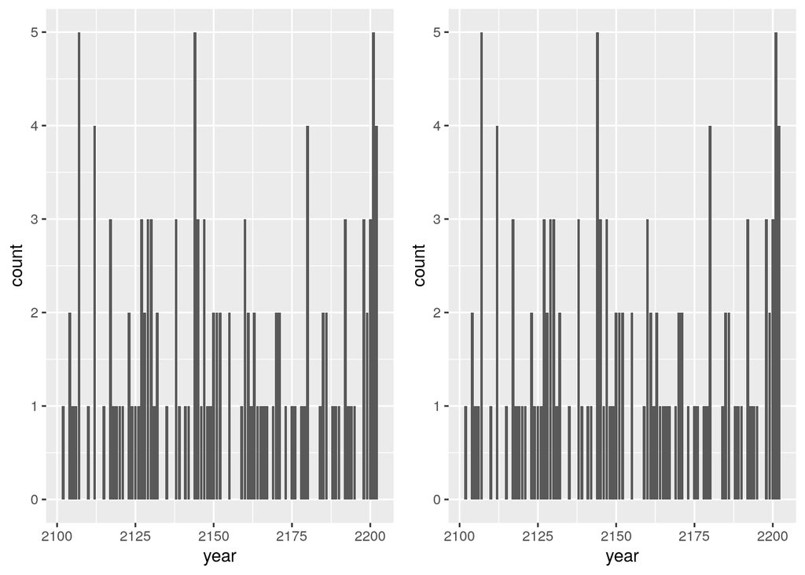

```r
year_mimic <- admissions_df %>%
  mutate(year = lubridate::year(ADMITTIME)) %>%
  ggplot(aes(x = year)) + geom_bar()

visit_occurrence_df <- as.data.frame(omop_visit_occurrence)

year_omop <- visit_occurrence_df %>%
  mutate(year = lubridate::year(visit_start_date)) %>%
  ggplot(aes(x = year)) + geom_bar()

grid.arrange(year_mimic, year_omop, ncol = 2)
```

```r
admissions %>%
  collect() %>%
  summarise(min_los = min(interval(date(ADMITTIME), date(DISCHTIME))/days(1)),
            max_los = max(interval(date(ADMITTIME), date(DISCHTIME))/days(1)),
            avg_los = mean(interval(date(ADMITTIME), date(DISCHTIME))/days(1)))
```

```
## # A tibble: 1 x 3
##   min_los max_los avg_los
##     <dbl>   <dbl>   <dbl>
## 1       0     124    9.34
```

```r
omop_visit_occurrence %>%
  collect() %>%
  summarise(min_los = min(interval(date(visit_start_datetime), date(visit_end_datetime))/days(1)),
            max_los = max(interval(date(visit_start_datetime), date(visit_end_datetime))/days(1)),
            avg_los = mean(interval(date(visit_start_datetime), date(visit_end_datetime))/days(1)))
```

```
## # A tibble: 1 x 3
##   min_los max_los avg_los
##     <dbl>   <dbl>   <dbl>
## 1       0     124    9.42
```

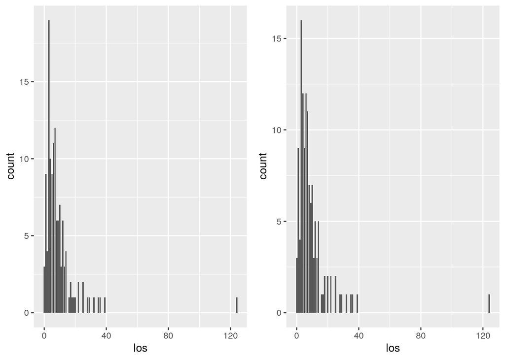

```r
los_mimic <- admissions_df %>%
  mutate(los = interval(date(ADMITTIME), date(DISCHTIME))/days(1)) %>%
  ggplot(aes(x = los)) + geom_bar()

los_omop <- visit_occurrence_df %>%
  mutate(los = interval(date(visit_start_datetime), date(visit_end_datetime))/days(1)) %>%
  ggplot(aes(x = los)) + geom_bar()

grid.arrange(los_mimic, los_omop, ncol = 2)
```

### Commparison

Temporal density seems consitent between the two data sets. The number of start dates per year is the same. Additionally, the minimum and maximum length of stay is the same. There is a slight difference between average length of stay and the distribution plot, which requires more examination.

# Investigation

The temporal data seems to have some inconsistensies. The average length of stay and lengh of stay distribution were not identical, despite having the same number of entries and using the same datetime format. We will try to determine why this may be the case.

I will start by just examining the number of stays for each length of stay duration in days.

### MIMIC-III LOS

```r
LOS_mimic <- admissions %>%
  collect() %>%
  summarise(LOS = interval(date(ADMITTIME), date(DISCHTIME))/days(1)) %>%
  select(LOS) %>%
  count(LOS, name = "MIMIC Counts per LOS")
```

### OMOP MIMIC

```r
LOS_omop <- omop_visit_occurrence %>%
  collect() %>%
  summarise(LOS = interval(date(visit_start_datetime), date(visit_end_datetime))/days(1)) %>%
  select(LOS) %>%
  count(LOS, name = "OMOP Counts per LOS")

#combine the results to easily compare differences
LOS <- merge(LOS_mimic, LOS_omop, by = "LOS")
LOS
```

```
##    LOS MIMIC Counts per LOS OMOP Counts per LOS
## 1    0                    3                   3
## 2    1                    9                   9
## 3    2                    4                   4
## 4    3                   19                  16
## 5    4                   10                  12
## 6    5                    9                   9
## 7    6                   11                  12
## 8    7                   12                  11
## 9    8                    6                   7
## 10   9                    6                   6
## 11  10                    7                   7
## 12  11                    3                   3
## 13  12                    6                   5
## 14  13                    3                   3
## 15  14                    4                   5
## 16  16                    1                   1
## 17  17                    2                   1
## 18  18                    1                   2
## 19  20                    1                   2
## 20  22                    2                   2
## 21  25                    2                   2
## 22  28                    1                   1
## 23  29                    1                   1
## 24  32                    1                   1
## 25  35                    1                   1
## 26  36                    1                   1
## 27  39                    1                   1
## 28 124                    1                   1
```

There are 19 visits with LOS = 3days in MIMIC while there are only 16 in the OMOP MIMIC data. There are only 10 visits with a LOS = 4days in MIMIC while there are 12 in OMOP. There are also different counts for 6-8 days. This explains why the average LOS is different, because the LOS counts per number of days are different.

Perhaps there is a difference in the actually mappings themselves, so I will extract and combine the actual admit datetimes and see if there is a 1:1 mapping there

```r
start_mimic <- admissions %>%
  collect() %>%
  select(ADMITTIME) %>%
  arrange(ADMITTIME)
rownames(start_mimic) <- start_mimic$ADMITTIME
start_omop <- omop_visit_occurrence %>%
  collect() %>%
  select(visit_start_datetime) %>%
  arrange(visit_start_datetime)
rownames(start_omop) <- start_omop$visit_start_datetime
starts <- merge(start_mimic, start_omop, by = "row.names")
starts %>%
  DT::datatable(options = list(scrollX = T))
```

|  | Row.names | ADMITTIME | visit_start_datetime |
| --- | --- | --- | --- |
| 1 | 2102-08-29 07:15:00 | 2102-08-29T07:15:00Z | 2102-08-29T07:15:00Z |
| 2 | 2105-05-29 18:18:00 | 2105-05-29T18:18:00Z | 2105-05-29T18:18:00Z |
| 3 | 2106-08-30 15:43:00 | 2106-08-30T15:43:00Z | 2106-08-30T15:43:00Z |
| 4 | 2107-01-16 11:33:00 | 2107-01-16T11:33:00Z | 2107-01-16T11:33:00Z |
| 5 | 2107-05-12 18:00:00 | 2107-05-12T18:00:00Z | 2107-05-12T18:00:00Z |
| 6 | 2110-12-29 18:03:00 | 2110-12-29T18:03:00Z | 2110-12-29T18:03:00Z |
| 7 | 2112-02-04 14:49:00 | 2112-02-04T14:49:00Z | 2112-02-04T14:49:00Z |
| 8 | 2112-05-04 08:00:00 | 2112-05-04T08:00:00Z | 2112-05-04T08:00:00Z |
| 9 | 2115-05-12 14:52:00 | 2115-05-12T14:52:00Z | 2115-05-12T14:52:00Z |
| 10 | 2121-12-07 20:49:00 | 2121-12-07T20:49:00Z | 2121-12-07T20:49:00Z |

[output cut: 27 more lines]

This table only has 37 entries, which means there were only 37 of the 129 encounters that had the exact same admit date and time. That would likely explain why I was getting different LOS distributions between the two.

When I looked at the github information from this mapping I found out that when the admission is an emergency, the admission start datetime becomes the emergency start datetime. This may explain my differences. The emergency time is EDREGTIME in the admissions table.

```r
admission_emerg <- admissions %>%
  collect() %>%
  filter(ADMISSION_TYPE == "EMERGENCY" & !is.na(EDREGTIME)) %>%
  mutate(los = interval(date(EDREGTIME), date(DISCHTIME))/days(1))
admission_nonemerg <- admissions %>%
  filter(ADMISSION_TYPE != "EMERGENCY" | is.na(EDREGTIME)) %>%
  collect() %>%
  mutate(los = interval(date(ADMITTIME), date(DISCHTIME))/days(1))
admission_emerg <- rbind(admission_emerg, admission_nonemerg)

admission_emerg %>%
  select(los) %>%
  summarise(min_los = min(los),
            max_los = max(los),
            avg_los = mean(los))
```

```
## # A tibble: 1 x 3
##   min_los max_los avg_los
##     <dbl>   <dbl>   <dbl>
## 1       0     124    9.42
```

```r
omop_visit_occurrence %>%
  collect() %>%
  summarise(min_los = min(interval(date(visit_start_datetime), date(visit_end_datetime))/days(1)),
            max_los = max(interval(date(visit_start_datetime), date(visit_end_datetime))/days(1)),
            avg_los = mean(interval(date(visit_start_datetime), date(visit_end_datetime))/days(1)))
```

```
## # A tibble: 1 x 3
##   min_los max_los avg_los
##     <dbl>   <dbl>   <dbl>
## 1       0     124    9.42
```

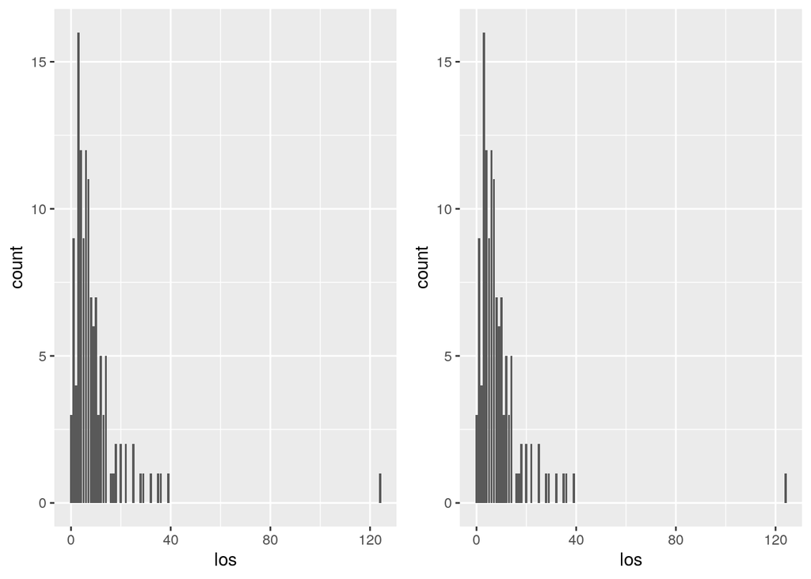

```r
los_mimic <- admission_emerg %>%
  ggplot(aes(x = los)) + geom_bar()

los_omop <- visit_occurrence_df %>%
  mutate(los = interval(date(visit_start_datetime), date(visit_end_datetime))/days(1)) %>%
  ggplot(aes(x = los)) + geom_bar()

grid.arrange(los_mimic, los_omop, ncol = 2)
```

Changing so length of stay from the admissions table in MIMIC-III is calculated using the Emergency start time (when available) fixes the discrepencies found in the temporal data!

### Conclusions/Explanations: The discrepancies between the encounter lengths in days was due to a difference in the mapping between MIMICIII and OMOP:

- the ADMITTIME does not always match the visit_start_datetime in the OMOP MIMIC mapping. It only matches for 37 of the cases.
- the visit_start_datetime is not always the the exact time the patient was admitted. If the admission type was “EMERGENCY”, then the start of the emergency was used as the visit_start_datetime instead of ADMITTIME.

# Analyze impact of data quality findings on research

Based on these findings, I might not want to use the OMOP model. In the mapping process, the visit_start_datetime varies depending whether or not the ADMISSION_TYPE was EMERGENCY. If it was an emergency, then the EDREGTIME is used instead. However, for some EMERGENCY admissions, there is no EDREGTIME available. This could cause some problems when doing anaylsis that is specific to emergencies. There would not be a consistent start time type (Emergency start vs Hospital admission start) used for the OMOP data. However, if the admission type (Emergency or Non-Emergency) is not important to the analysis being done, then the OMOP data is likely better due to being a CDM. The encounters are well preserved between the two data models for atemporal data density and data distributions.